# PA1_Template

Morgan Winston

April 18, 2015

Loading and preprocessing the data

```r
data <- read.csv("/Users/Morgan Sarah Winston/Desktop/activity.csv")
```

What is mean total number of steps taken per day? Create histogram of total number of steps taken each day and produce mean and median

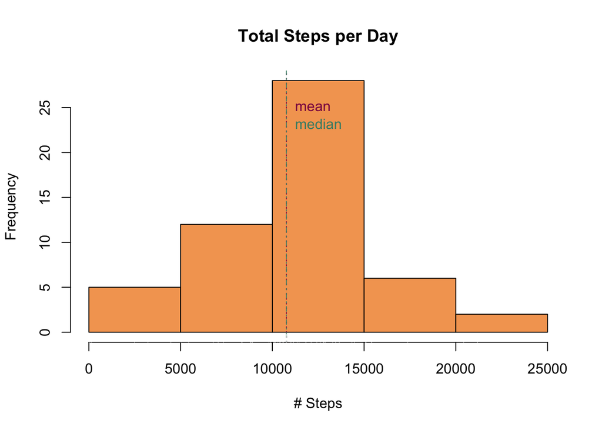

```r
completes<-subset(data,complete.cases(data)==TRUE)
splitDay<-split(completes, completes$date, drop=TRUE)
dailySteps<-sapply(splitDay, function(x) sum(x$steps))
hist(dailySteps, main="Total Steps per Day", xlab="# Steps", col="sandybrown")
abline(v=mean(dailySteps), lty=3, col="deeppink4")
abline(v=median(dailySteps), lty=4, col="aquamarine4")
text(mean(dailySteps),25,labels="mean",pos=4,col="deeppink4")
text(mean(dailySteps),23,labels="median",pos=4,col="aquamarine4")
rug(dailySteps,col="white")
```

```r
summary(dailySteps)
```

```
##    Min. 1st Qu.  Median    Mean 3rd Qu.    Max.
##      41    8841   10760   10770   13290   21190
```

What is the average activity pattern? Create time series plot of 5-min interval and average number of steps taken averaged across all days

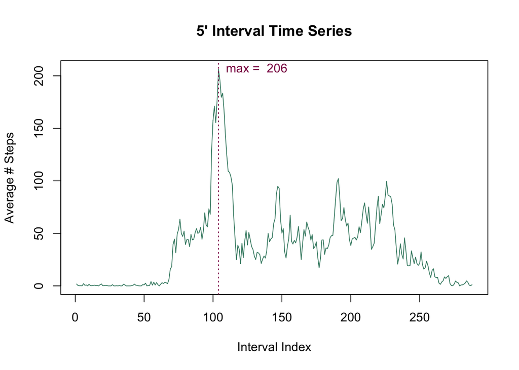

```r
splitInterval<-split(completes,completes$interval,drop=TRUE)
intervalAvg<-sapply(splitInterval,function(x) mean(x$steps))
plot(intervalAvg, type="l", main="5' Interval Time Series",
     ylab="Average # Steps",
     xlab="Interval Index", col="aquamarine4")
abline(v=which.max(intervalAvg), lty=3, col="deeppink4")
text(which.max(intervalAvg),max(intervalAvg),
     labels=paste("max = ",as.character(round(max(intervalAvg)))),
     pos=4, col="deeppink4")
```

```r
# Print interval that contains the maxiumum number of steps across all days
names(which.max(intervalAvg))
```

```
## [1] "835"
```

Input missing values: Calculate and report the total number of missing values in the dataset

```r
originalValue <- complete.cases(data)
nMissing <- length(originalValue[originalValue==FALSE])
nComplete <- length(originalValue[originalValue==TRUE])

nMissing
```

```
## [1] 2304
```

Fill in all of the missing values in the dataset using the mean across all days for 5-min interval which the NA occurs

```r
newData <- cbind(data,originalValue)
splitOrig<-split(newData,newData$originalValue, drop=TRUE)
for (row in 1:nrow(splitOrig[["FALSE"]])){
  splitOrig[["FALSE"]][row,1] <- round(subset(intervalAvg,names(intervalAvg) ==
                                                  as.character(splitOrig[["FALSE"]][row,3])))
}
newData <- rbind(splitOrig[["FALSE"]],splitOrig[["TRUE"]])
newData <- newData[with(newData, order(date, interval)), ]
```

Create a histogram for the new data, and calculate and report the mean and median total number of steps taken per day

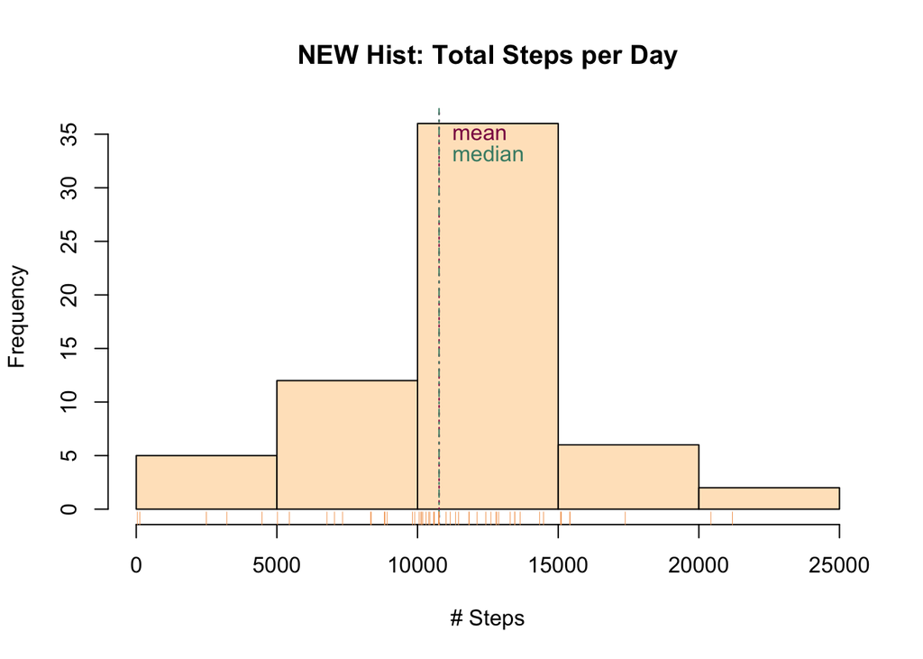

```r
splitNewByDay <- split(newData,newData$date, drop=TRUE)
dailyStepsNew <- sapply(splitNewByDay, function(x) sum(x$steps))

hist(dailyStepsNew, main="NEW Hist: Total Steps per Day", xlab="# Steps", col="bisque")
abline(v=mean(dailySteps), lty=3, col="deeppink4")
abline(v=median(dailySteps), lty=4, col="aquamarine4")
text(mean(dailySteps),35,labels="mean", pos=4, col="deeppink4")
text(mean(dailySteps),33,labels="median", pos=4, col="aquamarine4")
rug(dailyStepsNew,col="sandybrown")
```

```r
summary(dailyStepsNew)
```

```
##    Min. 1st Qu.  Median    Mean 3rd Qu.    Max.
##      41    9819   10760   10770   12810   21190
```

Are there differences in activity patterns between weekdays and weekends? Create new factor variable in the dataset with two levels (weekday and weekend)

```r
newData$date <- as.Date(strptime(newData$date, format="%Y-%m-%d"))
newData$day <- weekdays(newData$date)
for (i in 1:nrow(newData)) {
  if (newData[i,]$day %in% c("Saturday","Sunday")) {
    newData[i,]$day<-"weekend"
  }
  else{
    newData[i,]$day<-"weekday"
  }
}
```

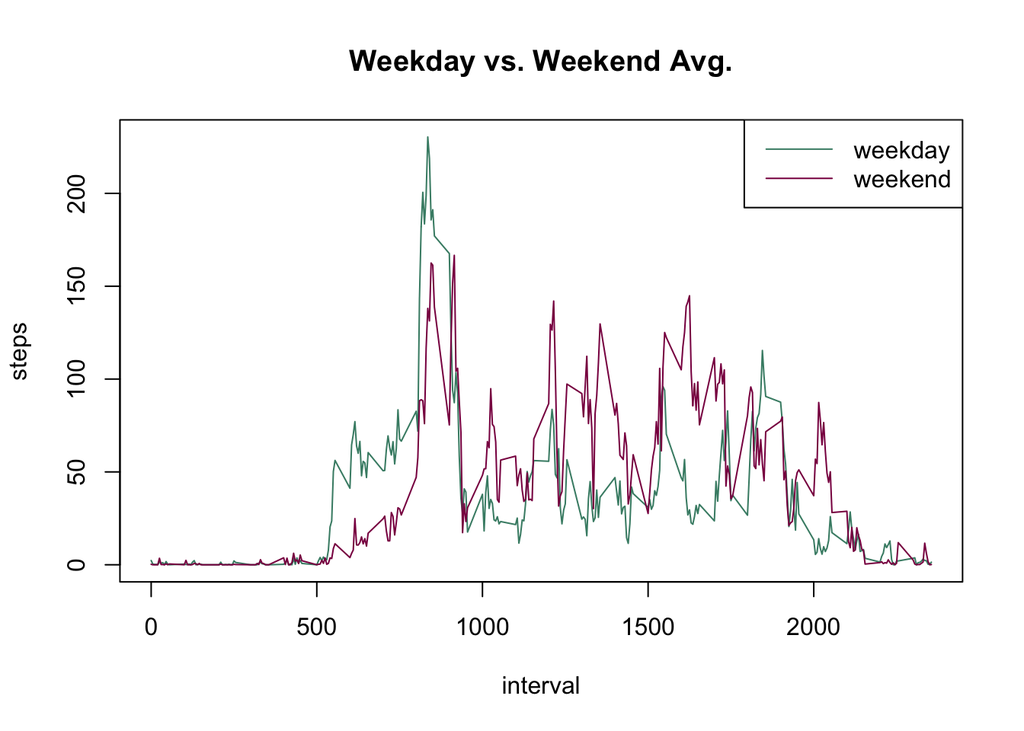

```r
stepsDay <- aggregate(newData$steps ~ newData$interval + newData$day, newData, mean)
names(stepsDay) <- c("interval", "day", "steps")
par(mfrow=c(1,1))
with(stepsDay, plot(steps ~ interval, type="n", main="Weekday vs. Weekend Avg."))
with(stepsDay[stepsDay$day == "weekday",], lines(steps ~ interval, type="l", col="aquamarine4"))
with(stepsDay[stepsDay$day == "weekend",], lines(steps ~ interval, type="l", col="deeppink4"))
legend("topright", lty=c(1,1), col = c("aquamarine4","deeppink4"), legend = c("weekday","weekend"), seg.len=3)
```